# Vergelijking aanvoer, import en export per soort

AER (STECF) aanvoer versus Visfederatie Markttool import/export

02 July 2026

# Inleiding

Dit document combineert twee databronnen om aanvoer, import en export per soort te vergelijken:

- **Aanvoer**: STECF AER-data — het gewicht dat Nederlandse vissersschepen daadwerkelijk aanlanden (levend gewicht, alle gebieden), ongeacht waar het vervolgens verkocht wordt.
- **Import/export**: Visfederatie Markttool — de handelsstromen die de Nederlandse grens over gaan, ongeacht wie de vis heeft gevangen of gekweekt.

**Twee belangrijke kanttekeningen:**

1. **Alleen gewicht, geen waarde.** De Markttool-download bevat een gewicht in *WFE* (Whole Fish Equivalent, kg) maar geen geldbedrag. AER heeft wel een waarde in euro’s, maar om appels met appels te vergelijken gebruiken we hier voor alle drie de stromen het **gewicht** (in ton).
2. **Soortkoppeling is een heuristiek.** De Markttool levert geen soortcode, alleen een vrije productomschrijving. Onderstaande code herkent soortnamen via trefwoorden in die omschrijving en koppelt ze aan dezelfde Nederlandse soortnamen als de AER-analyse. Soorten die niet door de Nederlandse vloot worden aangevoerd maar wel veel geïmporteerd worden (zalm, tonijn, pangasius, tilapia, alaska koolvis, …) krijgen daardoor terecht een aanvoer van (bijna) nul.

# Soortenlijst (gedeeld tussen AER en Markttool)

# Markttool import/export inlezen

# Vergelijkingsdataset opbouwen

# Aanvoer, import en export per soort

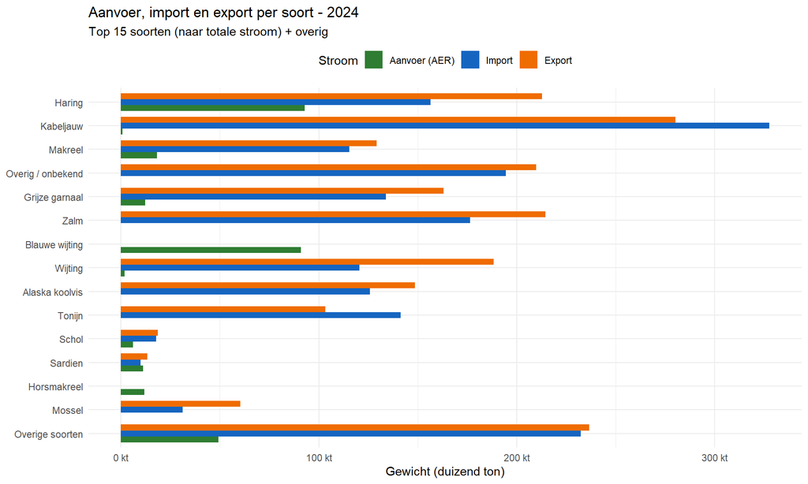

## Tabel: aanvoer, import, export en handelsrol per soort

De kolom `export_dekking` geeft aan hoe de exportstroom zich verhoudt tot de aanvoer: een waarde boven 100% betekent dat er meer wordt geëxporteerd dan er in Nederland wordt aangevoerd — een aanwijzing dat (deels) geïmporteerde vis wordt doorgevoerd/geëxporteerd.

| soort_nl | aanvoer_ton | import_ton | export_ton | netto_handel | export_dekking |
| --- | --- | --- | --- | --- | --- |
| Kabeljauw | 800 | 327611 | 280302 | 47309 | 35 048% |
| Haring | 92772 | 156425 | 212871 | -56446 | 229% |
| Overig / onbekend | 0 | 194476 | 209815 | -15339 | NA |
| Zalm | 0 | 176460 | 214541 | -38081 | NA |
| Wijting | 1845 | 120491 | 188347 | -67855 | 10 210% |
| Grijze garnaal | 12299 | 133990 | 163091 | -29100 | 1 326% |
| Alaska koolvis | 0 | 125835 | 148656 | -22821 | NA |
| Makreel | 18154 | 115503 | 129287 | -13784 | 712% |
| Tonijn | 0 | 141261 | 103366 | 37895 | NA |
| Mossel | 0 | 31250 | 60430 | -29180 | NA |

[output cut: 15 more lines]

# Wat blijft er in Nederland (aanvoer + import − export)

Het verschil tussen wat binnenkomt (aanvoer + import) en wat weer wordt geëxporteerd, is een grove schatting van wat er in Nederland “blijft”: een mix van **binnenlandse consumptie**, **verwerkings-/snijverlies** (bijvoorbeeld filerering, waardoor het WFE-gewicht van het eindproduct lager is dan het gewicht dat als grondstof binnenkomt) en niet-geregistreerde voorraadmutaties. Het is dus geen zuiver consumptiecijfer, maar een massabalans-indicator. Omdat de Markttool-gewichten al in WFE zijn uitgedrukt — precies bedoeld om vergelijkbaar te zijn met aanvoercijfers — is deze optelling inhoudelijk consistent.

Een negatieve waarde (meer export dan aanbod) kan wijzen op voorraadgebruik uit eerdere jaren, op afwijkingen tussen de AER- en Markttool-periodes, of op onvolledige soortherkenning in één van beide bronnen.

## Aanbod versus export per soort

De grijze balk is het totale aanbod (aanvoer + import); de oranje balk erin is wat daarvan weer wordt geëxporteerd. Het grijze stuk dat boven de oranje balk uitsteekt, is wat er (naar schatting) in Nederland blijft.

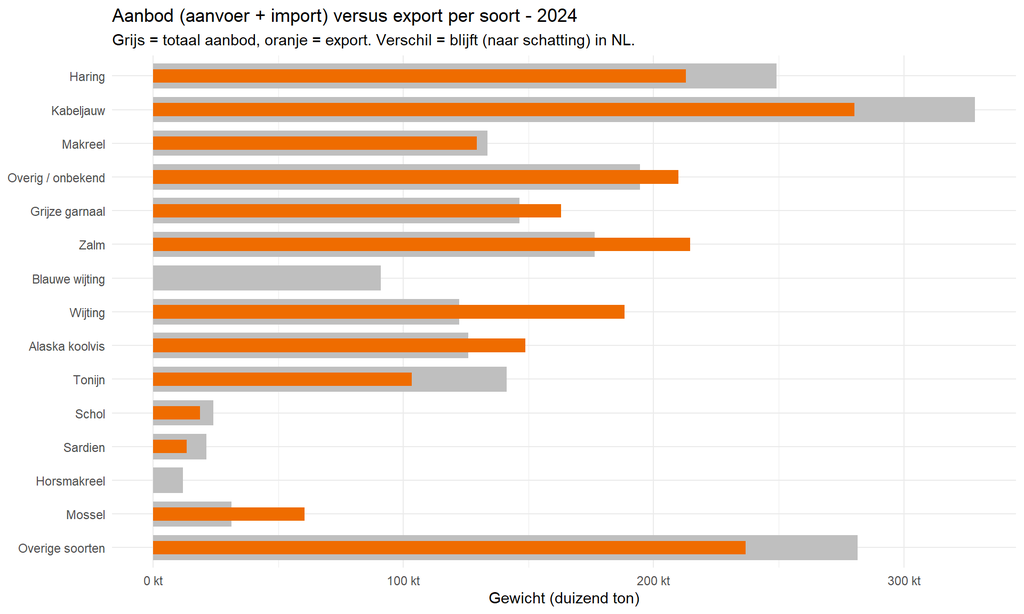

## Tabel: wat blijft er in Nederland, per soort

| soort_nl | aanvoer_ton | import_ton | aanbod_totaal | export_ton | beschikbaar_nl | aandeel_beschikbaar |
| --- | --- | --- | --- | --- | --- | --- |
| Kabeljauw | 800 | 327611 | 328411 | 280302 | 48109 | 15% |
| Haring | 92772 | 156425 | 249196 | 212871 | 36326 | 15% |
| Overig / onbekend | 0 | 194476 | 194476 | 209815 | -15339 | -8% |
| Zalm | 0 | 176460 | 176460 | 214541 | -38081 | -22% |
| Grijze garnaal | 12299 | 133990 | 146290 | 163091 | -16801 | -11% |
| Tonijn | 0 | 141261 | 141261 | 103366 | 37895 | 27% |
| Makreel | 18154 | 115503 | 133657 | 129287 | 4371 | 3% |
| Alaska koolvis | 0 | 125835 | 125835 | 148656 | -22821 | -18% |
| Wijting | 1845 | 120491 | 122336 | 188347 | -66011 | -54% |
| Blauwe wijting | 90872 | 0 | 90872 | 0 | 90872 | 100% |

[output cut: 15 more lines]

## Totaal, alle soorten samen

| aanvoer_ton | import_ton | aanbod_totaal | export_ton | beschikbaar_nl | aandeel_beschikbaar |
| --- | --- | --- | --- | --- | --- |
| 295,076 | 1,783,587 | 2,078,664 | 1,979,383 | 99,281 | 5% |

# Volgende stappen

- Zodra er Markttool-downloads voor meerdere jaren beschikbaar zijn, toont `vergelijking_plot` automatisch een paneel per jaar (via `facet_wrap(~jaar)`) in plaats van alleen het laatste jaar.
- Als een Markttool-download met waarde in euro’s beschikbaar komt, kan dezelfde opzet gebruikt worden om aanvoerwaarde, importwaarde en exportwaarde te vergelijken in plaats van alleen gewicht.
- Soorten in “Overig / onbekend” (geen trefwoord herkend) of zonder AER-code kun je opzoeken door `markttool_data |> filter(soort_nl == "Overig / onbekend") |> count(beschrijving, sort = TRUE)` te draaien, en vervolgens `markttool_soort_lookup` aan te vullen.